# Elections 19: Project 6

How well are women represented on the different political levels?

SRF Data, Angelo Zehr (angelo.zehr@srf.ch)

August 2019

### Preliminary Remarks

This document describes the pre-processing and exploratory analysis of the data set that is the basis of the article [Die grössten Hürden für Frauen in der Schweizer Politik](https://srf.ch/news/schweiz/wahlen-2019/wahlen-2019-die-groessten-huerden-fuer-frauen-in-der-schweizer-politik) published on srf.ch.

SRF Data attaches importance to the fact that the data pre-processing and analysis can be reproduced and checked. SRF Data believes in the principle of open data, but also open and comprehensible methods. On the other hand, it should be possible for third parties to build on this preparatory work and thus generate further evaluations or applications.

### R-Script & Data

The preprocessing and analysis of the data was conducted in the [R project for statistical computing](https://www.r-project.org/). The RMarkdown script used to generate this document and all the resulting data can be downloaded [under this link](http://srfdata.github.io/2019-09-women-in-politics/rscript.zip). Through executing `main.Rmd`, the herein described process can be reproduced and this document can be generated. In the course of this, data from the folder `input` will be processed and results will be written to `output`.

SRF Data uses Timo Grossenbacher’s rddj-template as the basis for its R scripts. If you have problems executing this script, it may help to study the instructions from the rddj-template.

This report was generated on 2019-09-12 17:07:41. R version: 3.5.3 on x86_64-apple-darwin15.6.0. For this report, CRAN packages as of 2019-03-01 were used.

### GitHub

The code for the herein described process can also be freely downloaded from https://github.com/srfdata/2019-09-women-in-politics.

### License

2019-09-women-in-politics by [SRF Data](https://github.com/srfdata/2019-09-women-in-politics) is licensed under a [Creative Commons Namensnennung - Attribution ShareAlike 4.0 International License](http://creativecommons.org/licenses/by-sa/4.0/).

### Other projects

Code and data by [SRF Data](https://srf.ch/data) are available on https://srfdata.github.io.

### Disclaimer

The published information has been carefully compiled, but does not claim to be up-to-date, complete or correct. No liability is assumed for damages arising from the use of this script or the information drawn from it. This also applies to contents of third parties which are accessible via this offer.

### Data description of output files

#### `candidates_per_gender_per_year.csv`

| Attribute | Type | Description |
| --- | --- | --- |
| year | Number | Year of measurement |
| category | Enum | Either “running” or “elected” |
| share | Number | Share of women as decimal |

#### `candidates_per_gender_per_party_and_year.csv`

| Attribute | Type | Description |
| --- | --- | --- |
| year | Number | Year of measurement |
| category | Enum | Either “running” or “elected” |
| party | Number | Party in question |
| n | Number | Number of candidates in that canton, party, year and category |
| share | Number | Share of women as decimal |

#### `candidates_detailed.csv`

| Attribute | Type | Description |
| --- | --- | --- |
| party | Number | Party in question |
| canton | Number | Canton of measurement |
| year | Number | Year of measurement |
| n | Number | Number of candidates in that canton, party and year |
| share | Number | Share of women as decimal |

### Original source

#### Data for 2019

-> `input/candidates_2019.csv`

Information about the candidates running this year was acquired by [smartvote](https://smartvote.ch). As we cannot distribute any proprietary material from them, we have reduced the columns to those necessary for this analysis: ID, name, gender, district (canton) and party. The export was done via their API on the 6th of September 2019 with 4596 unique candidates.

Partiese were simplified as follows:

- SP = SP + JUSO + JSP
- GPS = GPS + JG + JGBNW + ALG + BastA
- GLP = GLP + JGLP
- BDP = BDP + JBDP
- CVP = CVP + JCVP + CSV
- FDP = FDP + JFS + LDP + JLDP
- SVP = SVP + JSVP

#### Gender Ratios by Party and Canton and Year

-> `input/su-d-17.02.02.05.02.06.xlsx`

[Candidates running](https://www.bfs.admin.ch/bfs/de/home/statistiken/kataloge-datenbanken/tabellen.assetdetail.284079.html) provided by the Federal Statistical Office.

Footnotes were removed: ¹ Stille Wahl ² Inkl. Vigilance/Genf

-> `input/je-d-17.02.02.02.01.02.xlsx`

[Candidates elected](https://www.bfs.admin.ch/bfs/de/home/statistiken/kataloge-datenbanken/tabellen.assetdetail.217221.html) provided by the Federal Statistical Office.

Footnotes were removed: 1) 2009: Fusion von FDP und LPS auf nationaler Ebene unter der Bezeichnung “FDP.Die Liberalen”. Fusion von FDP und LP im Kanton Waadt im Jahr 2012. Im Kanton Basel-Stadt haben FDP und LP nicht fusioniert. Da die LP-BS Mitglied der „FDP.Die Liberalen Schweiz“ ist, wird das Mandat der LP-BS auf gesamtschweizerischer Ebene der FDP zugeteilt. 2) CSP-OW: Der Gewählte bleibt in der CVP-Fraktion.

as well as

1. Stille Wahl
2. BE: Die Vertreterin des Grünen Bündnis (FGA) wurde auf einer gemeinsamen Liste GPS/FGA gewählt.

## Vorbereitungen

```
## [1] "package package:rmarkdown detached"
```

### Packages definieren

```r
# from https://mran.revolutionanalytics.com/web/packages/checkpoint/vignettes/using-checkpoint-with-knitr.html
# if you don't need a package, remove it from here (commenting is probably not sufficient)
# tidyverse: see https://blog.rstudio.org/2016/09/15/tidyverse-1-0-0/
cat("
library(rstudioapi)
library(tidyverse) # ggplot2, dplyr, tidyr, readr, purrr, tibble
library(glue) # use glue directly without namespacing
library(magrittr) # pipes
library(readxl) # excel
library(scales) # scales for ggplot2
library(lintr) # code linting
library(rmarkdown)",
file = "manifest.R")
```

### Packages installieren

```r
# if checkpoint is not yet installed, install it (for people using this
# system for the first time)
if (!require(checkpoint)) {
  if (!require(devtools)) {
    install.packages("devtools", repos = "http://cran.us.r-project.org")
    require(devtools)
  }
  devtools::install_github("RevolutionAnalytics/checkpoint",
                           ref = "v0.3.2", # could be adapted later,
                           # as of now (beginning of July 2017
                           # this is the current release on CRAN)
                           repos = "http://cran.us.r-project.org")
  require(checkpoint)
}
# nolint start
if (!dir.exists("~/.checkpoint")) {
  dir.create("~/.checkpoint")
}
# nolint end
# install packages for the specified CRAN snapshot date
checkpoint(snapshotDate = package_date,
           project = path_to_wd,
           verbose = T,
           scanForPackages = T,
           use.knitr = F,
           R.version = R_version)
rm(package_date)
```

### Packages laden

```r
source("manifest.R")
unlink("manifest.R")
```

### Read data

```r
# map over election years and read data
# do each year twice, once for the candidates
# and once for the elected parliamentarians
suppressMessages(
  candidates_per_gender <- bind_rows(
    as.tibble(seq(1971, 2015, 4)) %>%
      mutate(
        category = "elected",
        path = "input/je-d-17.02.02.02.01.02.xlsx",
        skip = 3,
        n_max = 33
      ),
    as.tibble(seq(1971, 2015, 4)) %>%
      mutate(
        category = "running",
        path = "input/su-d-17.02.02.05.02.06.xlsx",
        skip = 4,
        n_max = 27
      )
  ) %>%
    # name first column
    rename(year = 1) %>%
    pmap_dfr(function(...) {
      current <- tibble(...)
      # the worksheets have the election year as its name
      data <- read_excel(
        path = current$path,
        sheet = as.character(current$year),
        skip = current$skip,
        n_max = current$n_max
      )

      # as each party has two columns, but only the first is correctly named,
      # we'll need to fill up the second one with the value of the first
      filled_colnames <- colnames(data) %>%
        as.tibble() %>%
        mutate(value = if_else(
          str_detect(value, "^\\.\\."),
          glue("{lag(value)}_M"), # add _M to second
          glue("{value}_F") # add _F to first
        )) %>%
        pull(value)

      # assign filled colnames
      colnames(data) <- filled_colnames

      # filter out empty rows
      data %>%
        rename(canton = 1) %>%
        filter(!is.na(canton)) %>%
        # remove columns without party data
        select(-starts_with("..")) %>%
        # make tidy
        gather(party, n, -canton) %>%
        # split party and gender into two
        separate(party, into = c("party", "gender"), sep = "_") %>%
        # convert to numeric (stars will be converted to NA)
        mutate(n = as.numeric(n)) %>%
        mutate(
          # add flag for running / elected
          category = current$category,
          # add year
          year = current$year
        )
    }) %>%
    # remove footnotes
    mutate(
      canton = str_replace(canton, " [¹²]$", ""),
      canton = str_replace(canton, " \\d\\)$", ""),
      party = str_replace(party, " [¹²]$", ""),
      party = str_replace(party, " \\d\\)$", "")
    ) %>%
    # fix typo (space missing between A. and Rh.)
    mutate(canton = str_replace(canton, "A.Rh.", "A. Rh.")) %>%
    # convert to factors
    mutate_at(vars(canton, party, gender, category), factor)
)
# integrity check: remove total from data and check whether values match
# save into separate variable
totals_per_canton <- candidates_per_gender %>%
  filter(canton == "Total") %>%
  select(-canton)

totals_per_party <- candidates_per_gender %>%
  filter(party == "Total") %>%
  select(-party)

# remove from original data
candidates_per_gender %<>%
  filter(canton != "Total" & party != "Total")
```

Integrity check: The following table should be empty as it compares the totals calculated by summing all values and the totals that the BFS provides in its tables.

```r
# compare
knitr::kable(
  candidates_per_gender %>%
    group_by(gender, party, year, category) %>%
    summarise(n_calc = sum(n, na.rm = TRUE)) %>%
    left_join(
      totals_per_canton,
      by = c("gender", "party", "year", "category")
    ) %>%
    # show only entries where the calculated total and the other total differ
    filter(n != n_calc)
)
```

| gender | party | year | category | n_calc | n |
| --- | --- | --- | --- | --- | --- |
| F | FDP | 2011 | running | 101 | 109 |
| F | FDP | 2015 | running | 138 | 142 |
| M | FDP | 2011 | elected | 22 | 23 |
| M | FDP | 2011 | running | 316 | 336 |
| M | FDP | 2015 | elected | 25 | 26 |
| M | FDP | 2015 | running | 310 | 321 |

```r
# clean up
rm(totals_per_canton)
```

It is currently not empty because in the years 2011 and 2015 the LPS is listed separately. The BFS makes the mistake to nevertheless add the LPS candidates to the total of the FDP. This means that our values are correct and the totals of the BFS are not. We throw away those totals and continue with our analysis. (Later we might group the LPS and the FDP.)

```r
# compare
knitr::kable(
  candidates_per_gender %>%
    group_by(gender, canton, year, category) %>%
    summarise(n_calc = sum(n, na.rm = TRUE)) %>%
    left_join(
      totals_per_party,
      by = c("gender", "canton", "year", "category")
    ) %>%
    # show only entries where the calculated total and the other total differ
    filter(n != n_calc)
)
```

gender canton year category n_calc n ——- ——- —– ——— ——- —

```r
# clean up
rm(totals_per_party)
```

The second table is empty, everything was read in correctly.

Let’s now add the LPS to the FDP.

```r
candidates_per_gender %<>%
  mutate(
    party = as.character(party),
    party = replace(party, party == "LPS", "FDP"),
    party = factor(party)
  ) %>%
  group_by(canton, party, gender, category, year) %>%
  summarise_at(
    vars(n),
    # we do not want everything to be zero
    function(n) {
      # if all entries are NA we want to leave it at that
      if (length(n) == length(n[is.na(n)])) {
        return(NA)
      }
      return(sum(n, na.rm = TRUE))
    }
  )
```

##### 2019

Read latest smartvote data to calculate numbers for 2019.

```r
candidates_2019 <- read_csv("input/candidates_2019.csv")
```

#### Add 2019 to data

```r
candidates_per_gender_2019 <- candidates_2019 %>%
  # reduce to important columns and unify with other data frame
  select(gender, party = group, canton = district) %>%
  # make cantons identical as well
  mutate(
    canton = case_when(
      canton == "Appenzell Ausserrhoden" ~ "Appenzell A. Rh.",
      canton == "Appenzell Innerrhoden" ~ "Appenzell I. Rh.",
      TRUE ~ canton
    ),
    # unify party names
    party = case_when(
      party == "BDP/PBD" ~ "BDP",
      party == "CVP/PDC" ~ "CVP",
      party == "FDP/PLR" ~ "FDP",
      party == "GLP/PVL" ~ "GLP",
      party == "GPS/PES" ~ "GPS",
      party == "SP/PS" ~ "SP",
      party == "SVP/UDC" ~ "SVP",
      TRUE ~ "Übrige"
    )
  ) %>%
  group_by(canton, party, gender) %>%
  summarise(n = n()) %>%
  ungroup() %>%
  # add missing columns to match data before 2019
  mutate(
    gender = str_to_upper(gender),
    category = "running",
    year = 2019
  )

candidates_per_gender_2019 %>%
  distinct(canton) %>%
  filter(!canton %in% levels(candidates_per_gender$canton))
```

```
## # A tibble: 0 x 1
## # … with 1 variable: canton <chr>
```

```r
candidates_per_gender_2019 %<>%
  filter(party %in% levels(candidates_per_gender$party)) %>%
  # make factors joinable by using same levels
  mutate(
    canton = factor(canton, levels = levels(candidates_per_gender$canton)),
    party = factor(party, levels = levels(candidates_per_gender$party)),
    gender = factor(gender, levels = levels(candidates_per_gender$gender)),
    category = factor(category, levels = levels(candidates_per_gender$category))
  )

# join
candidates_per_gender %<>%
  bind_rows(candidates_per_gender_2019)
```

#### Female Shares: Candidates running / elected

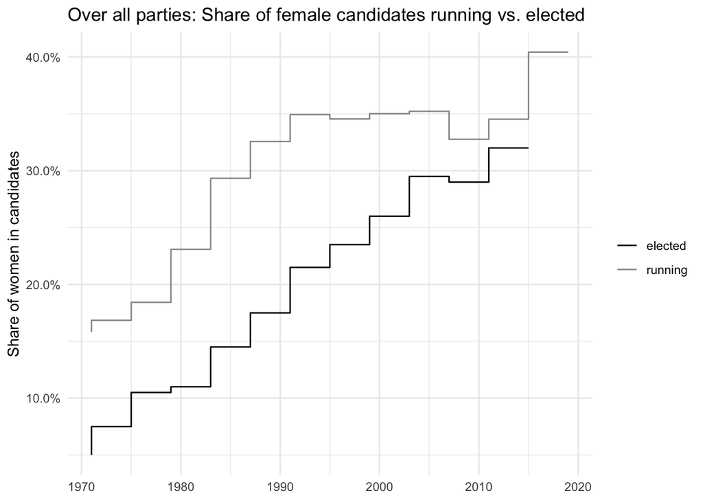

```r
# make less tidy by putting number of men and women into columns
candidates_per_gender %<>%
  spread(gender, n) %>%
  rename(women = `F`, men = `M`) %>%
  # replace NAs with zero where one of the values is present (men or women)
  mutate(
    women = ifelse(is.na(women) & !is.na(men), 0, women),
    men = ifelse(is.na(men) & !is.na(women), 0, men)
  ) %>%
  # calculate shares
  mutate(
    share_f = women / (women + men),
    share_m = men / (women + men)
  )

# calculate values over all parties
candidates_per_gender_per_year <- candidates_per_gender %>%
  group_by(year, category) %>%
  summarise(
    share = sum(women, na.rm = TRUE) /
      (sum(women, na.rm = TRUE) + sum(men, na.rm = TRUE))
  ) %>%
  ungroup() %>%
  # remove elected 2019
  filter(year != max(year) | category != "elected")

ggplot(
  candidates_per_gender_per_year,
  aes(
    x = year,
    y = share,
    group = category,
    color = category
  )
) +
  geom_step(direction = "vh") +
  scale_color_manual(values = c("#000000", "#999999")) +
  scale_y_continuous(labels = percent) +
  theme_minimal() +
  labs(
    title = "Over all parties: Share of female candidates running vs. elected",
    x = NULL,
    y = "Share of women in candidates",
    color = NULL
  )
```

##### By party

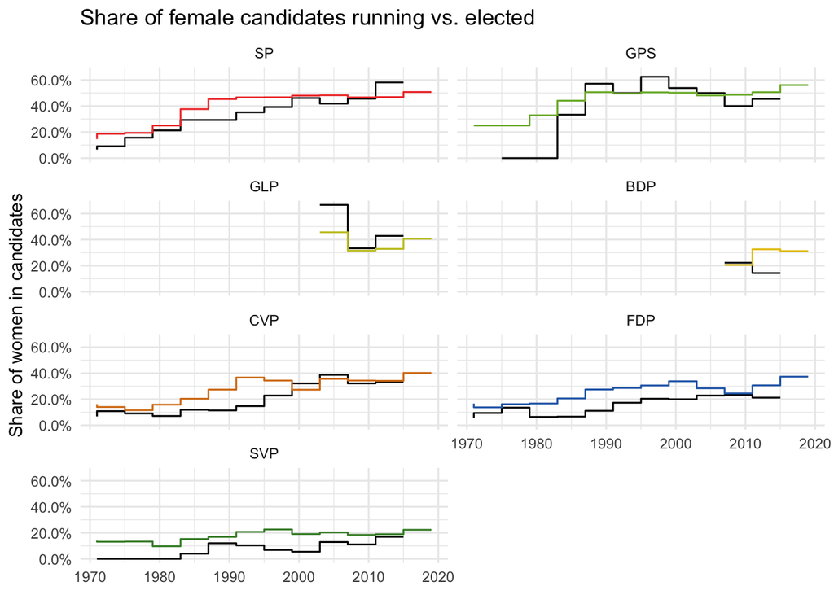

```r
party_colors <- c(
  "SP" = "#F03E35",
  "GPS" = "#7BB535",
  "GLP" = "#C4C429",
  "BDP" = "#E6C409",
  "CVP" = "#D67C15",
  "FDP" = "#2669B5",
  "SVP" = "#3F8A30"
)

# make copy with different names (add running)
party_colors_alt <- c(party_colors)
names(party_colors_alt) <- c(
  "SP_running",
  "GPS_running",
  "GLP_running",
  "BDP_running",
  "CVP_running",
  "FDP_running",
  "SVP_running"
)
# plus add black as a value for all parties for the elected candidates
party_colors_alt <- c(party_colors_alt, c(
  "SP_elected" = "#000000",
  "GPS_elected" = "#000000",
  "GLP_elected" = "#000000",
  "BDP_elected" = "#000000",
  "CVP_elected" = "#000000",
  "FDP_elected" = "#000000",
  "SVP_elected" = "#000000"
))

# save order of parties for factoring / sorting facets
party_order <- str_replace(names(party_colors_alt), "_.*$", "")[1:7]

# calculate values over all parties
candidates_per_gender_per_party_and_year <- candidates_per_gender %>%
  group_by(year, category, party) %>%
  summarise(
    women = sum(women, na.rm = TRUE),
    men = sum(men, na.rm = TRUE),
    share = women / (women + men)
  ) %>%
  ungroup() %>%
  # filter out elected 2019
  filter(year != max(year) | category != "elected")

# plot big 7
ggplot(
  candidates_per_gender_per_party_and_year %>%
    filter(party %in% party_order),
  aes(
    x = year,
    y = share,
    group = category,
    color = glue("{party}_{category}")
  )
) +
  geom_step(direction = "vh") +
  facet_wrap(~ factor(party, levels = party_order), ncol = 2) +
  scale_y_continuous(labels = percent) +
  scale_color_manual(values = party_colors_alt) +
  theme_minimal() +
  theme(legend.position = "none") +
  labs(
    title = "Share of female candidates running vs. elected",
    x = NULL,
    y = "Share of women in candidates"
  )
```

### Export

#### Candidates per gender/year

```r
write_csv(
  candidates_per_gender_per_year,
  "output/candidates_per_gender_per_year.csv"
)
```

#### Candidates per party/gender/year

```r
candidates_per_party_export <- candidates_per_gender_per_party_and_year %>%
  filter(party %in% party_order) %>%
  mutate(n = men + women) %>%
  select(year, category, party, n, share)

write_csv(
  candidates_per_party_export,
  "output/candidates_per_gender_per_party_and_year.csv"
)

# clean up
rm(candidates_per_party_export)
```

#### Candidates full details

```r
candidates_detailed_export <- candidates_per_gender %>%
  filter(party %in% party_order & !is.na(share_f) & category == "running") %>%
  mutate(n = men + women) %>%
  # replace canton names with abbrs
  left_join(
    read_csv("input/canton_names.csv") %>%
      select(canton_abbr = abbr, name),
    by = c("canton" = "name")
  ) %>%
  ungroup() %>%
  select(-canton, canton = canton_abbr) %>%
  select(party, canton, year, n, share = share_f)
write_csv(
  candidates_detailed_export,
  "output/candidates_detailed.csv"
)

# clean up
rm(candidates_detailed_export)
```

### Linting

Der Code in diesem RMarkdown wird mit lintr automatisch auf den Wickham’schen [tidyverse style guide](http://style.tidyverse.org/) überprüft.

```r
lintr::lint(
  "main.Rmd",
  linters = lintr::with_defaults(commented_code_linter = NULL)
)
```